# Stats Inference Project

nkvasg

Friday, March 20, 2015

The exponential distribution can be simulated in R with rexp(n, lambda) where lambda is the rate parameter. The mean of exponential distribution is 1/lambda and the standard deviation is also 1/lambda. In this simulation, we investigate the distribution of averages of 40 numbers sampled from exponential distribution with lambda=0.2.

The code below is to do a thousand simulations with 40 exponentials.

```r
# Data
lambda <- 0.2
nsim <- 1000
n <- 40

# Set seed for reproducibility
set.seed(10)
sim <- matrix(rexp(nsim*n, lambda), nsim, n)
row_means <- rowMeans(sim)
```

The theoretical mean of the exponential distribution will be 1/lambda.

The distribution of sample means is as in the graph below

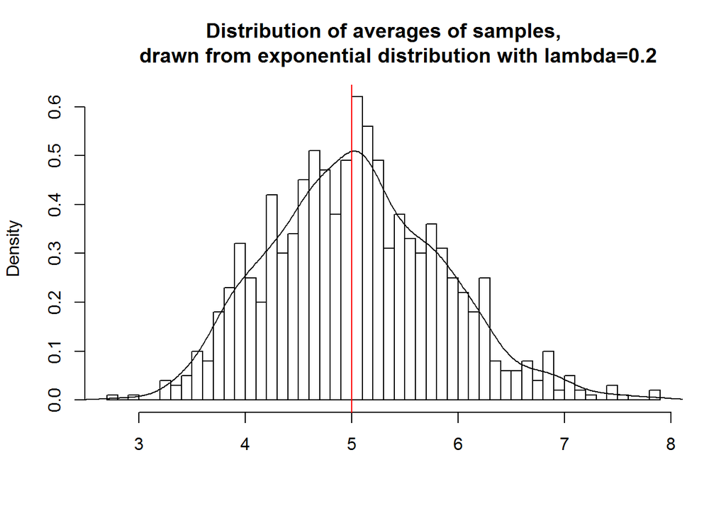

The variance of the sample in comparison with the theoretical variance of the distribution:

```r
# Variance
sd <- 1/lambda/sqrt(n)
var1 <- (1/lambda/sqrt(n))^2
var2 <- var(row_means)
var1
```

```
## [1] 0.625
```

```r
var2
```

```
## [1] 0.6541736
```

The distribution of sample means is centered at 4.9866 and the theoretical center of the distribution is 5. The variance of sample means is 0.654 where the theoretical variance of the distribution is 0.625.

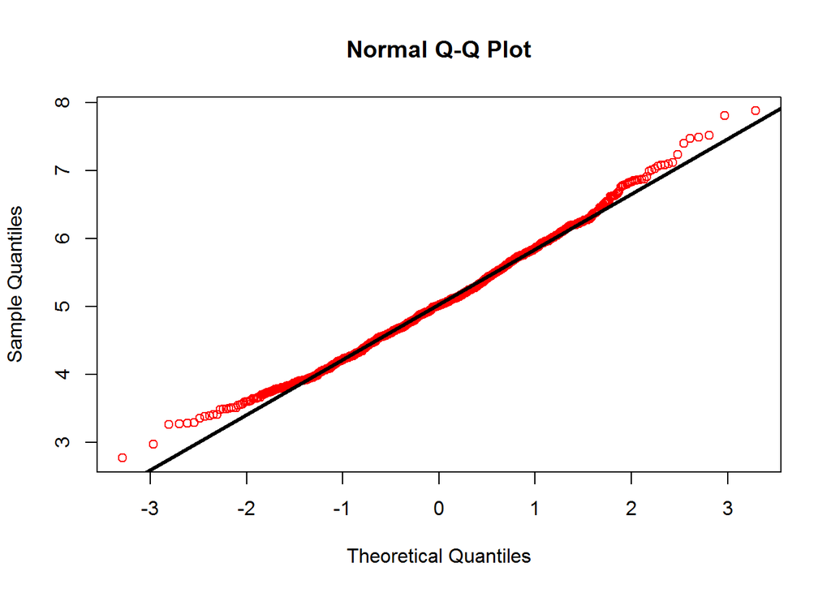